# Introduction to R and RStudio Day 1 JCSMR Workshop for Students https://github.com/numicator/ANU_R_workshop

### Vectorization

Vectorization means that when an operation is performed on a vector it involves all elements in that vector (not e.g. only the first element). All R functions (and operators) are *vectorized* - they operate on vectors. *In R there are no scalars - only vectors*.

```r
#lets first check simple arithmetic operators:
a <- 1:6
b <- 3:8
a
```

```
## [1] 1 2 3 4 5 6
```

```r
b
```

```
## [1] 3 4 5 6 7 8
```

```r
a + b
```

```
## [1]  4  6  8 10 12 14
```

```r
a * b
```

```
## [1]  3  8 15 24 35 48
```

So, how to multiply a multi-element vector by a single-element vector representing scalar?:

```r
a <- 2
b <- 3:8
a
```

```
## [1] 2
```

```r
b
```

```
## [1] 3 4 5 6 7 8
```

What will happen and why?

```r
a * b
```

```
## [1]  6  8 10 12 14 16
```

What actually happened is: The shorter vector *a* was *recycled* as many times as necessary to match length of the longer vector *b*. As *a* has only 1 element it was an equivalent of multiplying *b* by scalar *a*.

### Matrices

Now, lets quickly introduce a matrix.  
Matrix is a collection of elements arranged in a 2D rectangular layout. It is a vector where each element is a vector of the same length. All the matrix elements must be the same type (e.g. all numbers or all text, same as with vectors). In most cases, to be able to use *matrix algebra* we will use numeric matrices.  
To create a matrix in R we can use the function `matrix()`. The matrix function needs to know:

- Shape of the matrix - number of rows and columns.
- Value of the elements - a vector with as many elements as there are *cells* in the matrix.
- Filling order - how to fill the matrix with the elements, by columns or by rows.

$$M = \begin{pmatrix}1 & 2 & 3 & 4 \\ 5 & 6 & 7 & 8 \\ 9 & 10 & 11 & 12\end{pmatrix}$$

```r
M <- matrix(1:12, nrow = 3, ncol = 4, byrow = TRUE)
M
```

```
##      [,1] [,2] [,3] [,4]
## [1,]    1    2    3    4
## [2,]    5    6    7    8
## [3,]    9   10   11   12
```

We can check data type of a matrix. And check its dimensions with functions `dim()`, `nrow()`, and `ncol()`.

```r
typeof(M)
```

```
## [1] "integer"
```

```r
#chech the size of the matrix:
dim(M)   # rows and columns
```

```
## [1] 3 4
```

```r
nrow(M)  # only rows
```

```
## [1] 3
```

```r
ncol(M)  # only columns
```

```
## [1] 4
```

Let’s have an excercise doing some matrix algebra:
Define matrices`A` and `B`:
$$A = \begin{pmatrix}4 & 5 \\ 2 & 3\end{pmatrix},\quad
B = \begin{pmatrix}1/2 & 1 \\ -2 & -1\end{pmatrix}$$

```r
#define the matrices:
A <- matrix(c(4, 5, 2, 3), nrow = 2, ncol = 2, byrow = TRUE)
B <- matrix(c(0.5, 1, -2, -1), nrow = 2, ncol = 2, byrow = TRUE)
A
```

```
##      [,1] [,2]
## [1,]    4    5
## [2,]    2    3
```

```r
B
```

```
##      [,1] [,2]
## [1,]  0.5    1
## [2,] -2.0   -1
```

1. Find *A* + 2*B* and *A*<sup>2</sup>

```r
#A + 2B:
A + 2 * B
```

```
##      [,1] [,2]
## [1,]    5    7
## [2,]   -2    1
```

```r
#A square
A %*% A
```

```
##      [,1] [,2]
## [1,]   26   35
## [2,]   14   19
```

2. Find *AB*, *BA*, det *A*, det *B*, det(*AB*) and det(*BA*)

```r
#AB
A %*% B
```

```
##      [,1] [,2]
## [1,]   -8   -1
## [2,]   -5   -1
```

```r
#BA
B %*% A
```

```
##      [,1]  [,2]
## [1,]    4   5.5
## [2,]  -10 -13.0
```

```r
#det A, det B
det(A)
```

```
## [1] 2
```

```r
det(B)
```

```
## [1] 1.5
```

```r
#det AB, det BA
det(A %*% B)
```

```
## [1] 3
```

```r
det(B %*% A)
```

```
## [1] 3
```

3. Find *A*<sup>-1</sup> and *B*<sup>-1</sup>, check that det(*A*<sup>-1</sup>) = (det *A*)<sup>-1</sup> and det(*B*<sup>-1</sup>) = (det *B*)<sup>-1</sup>

```r
#inverse A and B
solve(A)
```

```
##      [,1] [,2]
## [1,]  1.5 -2.5
## [2,] -1.0  2.0
```

```r
solve(B)
```

```
##            [,1]       [,2]
## [1,] -0.6666667 -0.6666667
## [2,]  1.3333333  0.3333333
```

```r
#check that determinant from inversed matrix equals inverse of the determinant
1 / det(A)
```

```
## [1] 0.5
```

```r
det(solve(A))
```

```
## [1] 0.5
```

```r
1 / det(A) == det(solve(A))
```

```
## [1] FALSE
```

Why the last comparison above returned FALSE? How to perform that comparison correctly?

4. Check that (AB)<sup>-1</sup> = B<sup>-1</sup> A<sup>-1</sup>

```r
C <- solve(A %*% B)
D <- solve(B) %*% solve(A)

#How to check if two matrices are equal?
#we should never directly '==' two float point numbers!
#instead check if the difference between them is small enough:
abs(C - D) < .Machine$double.eps
```

```
##      [,1] [,2]
## [1,] TRUE TRUE
## [2,] TRUE TRUE
```

```r
all(abs(C - D) < .Machine$double.eps)
```

```
## [1] TRUE
```

### Vector and Matrix Indexing

slides 27-40

Now we know (sort of) how to perform operation of vectors, matrices and data.frames. But how to access specific elements in vectors or rows or columns of data in data frames? Rephrasing: How to **subset** a data structure?

Subsetting is done with use of indices. To access *n<sup>th</sup>* element of a vector *v* we use notation: *v*[*n*]. `[ ]` is the *indexing operator*.

```r
v <- 1:10
v
```

```
##  [1]  1  2  3  4  5  6  7  8  9 10
```

```r
#get 1st element
v[1]
```

```
## [1] 1
```

```r
#get 7th element
v[7]
```

```
## [1] 7
```

```r
#get elements from 3 to 6
v[3:6]
```

```
## [1] 3 4 5 6
```

```r
#how to get elements 2, 4, 5?
```

Similarly we index elements of a matrix, only this time we use two indices - first for the row, and second for the column. Lets get back to our *M* matrix

$$M = \begin{pmatrix}1 & 2 & 3 & 4 \\ 5 & 6 & 7 & 8 \\ 9 & 10 & 11 & 12\end{pmatrix}$$

```r
M <- matrix(1:12, nrow = 3, ncol = 4, byrow = TRUE)
M
```

```
##      [,1] [,2] [,3] [,4]
## [1,]    1    2    3    4
## [2,]    5    6    7    8
## [3,]    9   10   11   12
```

```r
#get element in second row, third column
M[2, 3]
```

```
## [1] 7
```

```r
#to get all elements from a row or a column simply ommit row or column index:
M[2, ]    #returns second row as a vector
```

```
## [1] 5 6 7 8
```

```r
M[, 3]    #return thirdcolumn as a vector
```

```
## [1]  3  7 11
```

An excercise: Write indexing statement which will subset the *M* matrix and return its bottom right corner:
$$\begin{pmatrix}7 & 8 \\ 11 & 12\end{pmatrix}$$

### Lists

slides 41-55

> Now we will focus on lists and data frames - the heterogenous counterparts of vectors and matrices.

List can be seen as a heterogeneous equivalent of vector. It can be created using function `list()`.

```r
l <- list(1, 2, 3, "last")
l
```

```
## [[1]]
## [1] 1
##
## [[2]]
## [1] 2
##
## [[3]]
## [1] 3
##
## [[4]]
## [1] "last"
```

To access elements of a list we use indexing in the same way as we did with vectors.

```r
#get second element
l[2]
```

```
## [[1]]
## [1] 2
```

```r
#why so many square brackets?
typeof(l[2])
```

```
## [1] "list"
```

Indexed element of list is a list (it’s not such a surprise, as an element of a vector is a vector of length 1).  
To accesss the element itself we need to ‘unlist’ it with function `unlist()`:

```r
unlist(l[2])
```

```
## [1] 2
```

Or use the `[[ ]]` operator:

```r
l[[2]]
```

```
## [1] 2
```

As an exercise we will create a list *l* with 3 elements, each being a vector of the same length (a list of vectors).  
First, we create the three vector variables (content doesn’t matter):

```r
#create the three vectors
v1 <- 1:4
v2 <- c(NA, NA, "c", "d") #NAs to mark that we are missing the first two elements in this vector
v3 <- 3:6
```

Now, we use the function list() to build a list with the vectors as the elements.

```r
#and now the list og vectors:
l <- list(v1, v2, v3)
l
```

```
## [[1]]
## [1] 1 2 3 4
##
## [[2]]
## [1] NA  NA  "c" "d"
##
## [[3]]
## [1] 3 4 5 6
```

The list have two dimensions: First is the list (elemnt 1, 2, 3), second is the element within each vector.  
To access e.g. 3<sup>rd</sup> element in the vector being the 2<sup>nd</sup> element of the list *l* we will need two indexes: First for the list, second for the element within the lists element (in the vector):

```r
l[[2]][3]
```

```
## [1] "c"
```

> Note that the list index uses the unlisting [[]] operator

### Named lists

The list elements may have their names to allow refering to them by their names rather than indexes.  
Lets create a list as above but this time we will name the three vector elements:

```r
l.named <- list(ord = v1, symbol = v2, value = v3)
l
```

```
## [[1]]
## [1] 1 2 3 4
##
## [[2]]
## [1] NA  NA  "c" "d"
##
## [[3]]
## [1] 3 4 5 6
```

```r
l.named
```

```
## $ord
## [1] 1 2 3 4
##
## $symbol
## [1] NA  NA  "c" "d"
##
## $value
## [1] 3 4 5 6
```

The named elements allow to reformulate question “How to access 3<sup>rd</sup> element in the vector which is the 2<sup>nd</sup> element of the list *l*?”  
Into: How to access 3nd element in the vector which has name *symbol* in the the list *l* ?  
To use name of an element we will need the `$` operator:

```r
#first, let access the 'symbol' element:
l.named$symbol
```

```
## [1] NA  NA  "c" "d"
```

```r
#have you noticed that the value was already unlisted?
#meaning we can do this:
l.named$symbol[3]
```

```
## [1] "c"
```

> It is of course still possible to refer to elements in named lists using the index notation.

### Data frames

Data frames are heterogeneous equivalents of matrices (heterogeneous means they can store data of various types): Each column can be of different data type, but within each column, all rows must be of the same data type. A bit like a simple spreadsheet (e.g. in Excel) or the *list of vectors* example above. Data frames are the basic, most comonly used data structures for storing and analyzing the experimental data.  
Let’s create a data frame with data as in the table (or a spreadsheet) below:

[output not shown]

To create a data frame we use a function called… `data.frame()`.  
We need to specify each column as a separate vector. All the vectores (columns) **must** have the same number of elements (rows):

```r
animals <- data.frame(animal = c("dog",   "cat",   "sea cucumber", "sea urchin"),
                        feel = c("furry", "furry", "squishy",      "spiny"),
                      weight = c(45,      8,       1.1,            0.8)
)

animals
```

```
##         animal    feel weight
## 1          dog   furry   45.0
## 2          cat   furry    8.0
## 3 sea cucumber squishy    1.1
## 4   sea urchin   spiny    0.8
```

Now, when we have our data in the `data.frame` structure we can save it as a file.  
R can work with many data file formats but the most popular ones are text files with fields separated either by a <TAB> or ‘,’ (coma). Those formats are know as ‘tab-separated values’ (TSV) and ‘coma-separated values’ (CSV). To save our `data.frame` as a file we can use the function `write.table()`.

> basic arguments to specify when writing a data.frame as a file
> - file - name of the file
> - sep - character to use as a separator, is tabulator
> - col.names - save column names?
> - row.names - save row names?
> - quote - surround non-numeric values in double-quotes?

```r
write.table(animals, file = "animals.tsv", sep = "\t", col.names = TRUE, row.names = FALSE, quote = FALSE)
```

Having the file created, we can now read it from a file to a `data.frame` with function `read.table()`

```r
animals <- read.table(file = "animals.tsv", sep = "\t", header = TRUE)
```

Data frame and matrix can be converted into each other with functions `as.matrix()`, to convert `data.frame` into `matrix` or `as.data.frame()` to do the oposite.

> Remember that `data.frame` is **heterogeneous** but `matrix` is **homogenous**. Conversion of `data.frame` into `matrix` **may result in type coercion**.

```r
#data frame animals;
animals
```

```
##         animal    feel weight
## 1          dog   furry   45.0
## 2          cat   furry    8.0
## 3 sea cucumber squishy    1.1
## 4   sea urchin   spiny    0.8
```

```r
#convert to matrix creatig matrix variable named 'animals.mx':
animals.mx <- as.matrix(animals)
animals.mx
```

```
##      animal         feel      weight
## [1,] "dog"          "furry"   "45.0"
## [2,] "cat"          "furry"   " 8.0"
## [3,] "sea cucumber" "squishy" " 1.1"
## [4,] "sea urchin"   "spiny"   " 0.8"
```

Note that the data type of matrix *animals.mx* was coerced to character.

```r
#check data type
typeof(animals.mx)
```

```
## [1] "character"
```

## Type and class conversions:

Objects of different type (or class) can be converted into each other using the as.<something>() functions (e.g. the `as.matrix()` above). Object can also by queried if they are of spefic type/class using the is.<something>() functions (e.g. `is.matrix()` or `is.integer()`).  
Conversions to character (anything can be converted to character with more or less sens):

```r
as.character(1e2)
```

```
## [1] "100"
```

```r
as.character(TRUE)
```

```
## [1] "TRUE"
```

```r
#converting to character with formating
sprintf("%10.2e %s", 1024 * 10, "BUM!")
```

```
## [1] "  1.02e+04 BUM!"
```

Conversions between integer and double:

```r
as.integer(2.7)             #will cutoff the decimal part!
```

```
## [1] 2
```

```r
as.integer(round(2.7, 0))   #use thr round function first
```

```
## [1] 3
```

```r
as.double("3.14159265")     #we can convert from characted too
```

```
## [1] 3.141593
```

remember to use the `as.integer()` function not just `integer()`:

```r
integer(2.7)
```

```
## [1] 0 0
```

```r
double("10.16")
```

```
##  [1] 0 0 0 0 0 0 0 0 0 0
```

```r
# the functions above create vectors of given type with given number of elements, not convert between types!!!
```

Conversions between vector and list:

```r
x <- c(first = 1, second = 2, third = 3)
class(x)
```

```
## [1] "numeric"
```

```r
print(x)
```

```
##  first second  third
##      1      2      3
```

```r
x.ls <- as.list(x)
class(x.ls)
```

```
## [1] "list"
```

```r
print(x.ls)
```

```
## $first
## [1] 1
##
## $second
## [1] 2
##
## $third
## [1] 3
```

```r
x.ls.v <- as.vector(x.ls)   #doesn't work as expected! output is still a list
class(x.ls.v)
```

```
## [1] "list"
```

```r
x.ls.v <- unlist(x.ls)      #we need to use unlist() instead (as.vector only strips the attributes)
class(x.ls.v)
```

```
## [1] "numeric"
```

```r
print(x.ls.v)
```

```
##  first second  third
##      1      2      3
```

```r
attributes(as.vector(x.ls))
```

```
## $names
## [1] "first"  "second" "third"
```

Conversions between matrix and data.frame:

```r
x <- matrix(1:6, ncol = 2, dimnames = list(LETTERS[1:3], letters[24:25]))
class(x)
```

```
## [1] "matrix"
```

```r
print(x)
```

```
##   x y
## A 1 4
## B 2 5
## C 3 6
```

```r
x.df <- as.data.frame(x)
class(x.df)
```

```
## [1] "data.frame"
```

```r
print(x.df)
```

```
##   x y
## A 1 4
## B 2 5
## C 3 6
```

```r
x.df.mx <- as.matrix(x.df)
class(x.df.mx)
```

```
## [1] "matrix"
```

```r
print(x.df.mx)
```

```
##   x y
## A 1 4
## B 2 5
## C 3 6
```

# Working with data, The Gapminder Example

Gapminder Foundation is a non-profit venture, that promotes sustainable global development and achievement of the United Nations Millennium Development Goals by increased use and understanding of statistics and other information about social, economic and environmental development at local, national and global levels. The data used here is an excerpt of the data available at http://gapminder.org:  
For each of the 142 countries on 5 continents provides values for:

- life expectancy,
- GDP per capita,
- population

The data was collected every 5 years from year 1952 to 2007.

## Exercise 1: Get the data

1. Download the gapminder.tsv data file from http://leucon.anu.edu.au/marcin/r_data/gapminder.tsv
2. Save the file into your project’s directory.
3. Open the gapminder.tsv file in RStudio editor.
4. Identify column separator (is it tabulator or ‘,’?).
5. Read data from gapminder.tsv into data frame variable `gapminder`, use `read.table` function

```r
gapminder <- read.table("gapminder.tsv", header = TRUE, sep = "\t")
```

## Exercise 2: Check the data

1. View data in `gapminder` using RStudion Data Viewer.

| country | year | pop | continent | lifeExp | gdpPercap |
| --- | --- | --- | --- | --- | --- |
| Afghanistan | 1952 | 8425333 | Asia | 28.801 | 779.4453 |
| Afghanistan | 1957 | 9240934 | Asia | 30.332 | 820.8530 |
| Afghanistan | 1962 | 10267083 | Asia | 31.997 | 853.1007 |
| Afghanistan | 1967 | 11537966 | Asia | 34.020 | 836.1971 |
| Afghanistan | 1972 | 13079460 | Asia | 36.088 | 739.9811 |
| Afghanistan | 1977 | 14880372 | Asia | 38.438 | 786.1134 |

2. Analyze structure of `gapminder` in RStudion Environment panel and using function `str`.

```r
str(gapminder)
```

```
## 'data.frame':    1704 obs. of  6 variables:
##  $ country  : Factor w/ 142 levels "Afghanistan",..: 1 1 1 1 1 1 1 1 1 1 ...
##  $ year     : int  1952 1957 1962 1967 1972 1977 1982 1987 1992 1997 ...
##  $ pop      : num  8425333 9240934 10267083 11537966 13079460 ...
##  $ continent: Factor w/ 5 levels "Africa","Americas",..: 3 3 3 3 3 3 3 3 3 3 ...
##  $ lifeExp  : num  28.8 30.3 32 34 36.1 ...
##  $ gdpPercap: num  779 821 853 836 740 ...
```

3. Print out a few first and last rows of `gapminder` with functions `head` and `tail`.

```r
head(gapminder, n = 3)
```

```
##       country year      pop continent lifeExp gdpPercap
## 1 Afghanistan 1952  8425333      Asia  28.801  779.4453
## 2 Afghanistan 1957  9240934      Asia  30.332  820.8530
## 3 Afghanistan 1962 10267083      Asia  31.997  853.1007
```

```r
tail(gapminder, n = 3)
```

```
##       country year      pop continent lifeExp gdpPercap
## 1702 Zimbabwe 1997 11404948    Africa  46.809  792.4500
## 1703 Zimbabwe 2002 11926563    Africa  39.989  672.0386
## 1704 Zimbabwe 2007 12311143    Africa  43.487  469.7093
```

4. Explore the data with basic statistics: Calculate mean and standard deviation for columns (variables) `lifeExp` and `gdpPercap`; use functions `summary`, `mean`, `sd`.

> Hint: Access columns with `$` operator.

```r
#basic stats for variable lifeExp
mean(gapminder$lifeExp)
```

```
## [1] 59.47444
```

```r
sd(gapminder$lifeExp)
```

```
## [1] 12.91711
```

```r
summary(gapminder$lifeExp)
```

```
##    Min. 1st Qu.  Median    Mean 3rd Qu.    Max.
##   23.60   48.20   60.71   59.47   70.85   82.60
```

```r
#basic stats for variable gdpPercap
mean(gapminder$gdpPercap)
```

```
## [1] 7215.327
```

```r
sd(gapminder$gdpPercap)
```

```
## [1] 9857.455
```

```r
summary(gapminder$gdpPercap)
```

```
##     Min.  1st Qu.   Median     Mean  3rd Qu.     Max.
##    241.2   1202.1   3531.8   7215.3   9325.5 113523.1
```

## Exercise 3: Calculate and print mean `lifeExp` for continent ‘Oceania’ in 21st century.

1. Select rows where column `continent` equals to ‘Oceania’. Use indexing with logical expression and the subsetting operator `$`.

```r
#using function head to limit printout
head(gapminder[gapminder$continent == 'Oceania', ])
```

```
##      country year      pop continent lifeExp gdpPercap
## 61 Australia 1952  8691212   Oceania   69.12  10039.60
## 62 Australia 1957  9712569   Oceania   70.33  10949.65
## 63 Australia 1962 10794968   Oceania   70.93  12217.23
## 64 Australia 1967 11872264   Oceania   71.10  14526.12
## 65 Australia 1972 13177000   Oceania   71.93  16788.63
## 66 Australia 1977 14074100   Oceania   73.49  18334.20
```

2. Similarly select rows where column `year` is greater or equal 2000 (21 century).

```r
#using function head to limit printout
head(gapminder[gapminder$year >= 2000, ])
```

```
##        country year      pop continent lifeExp gdpPercap
## 11 Afghanistan 2002 25268405      Asia  42.129  726.7341
## 12 Afghanistan 2007 31889923      Asia  43.828  974.5803
## 23     Albania 2002  3508512    Europe  75.651 4604.2117
## 24     Albania 2007  3600523    Europe  76.423 5937.0295
## 35     Algeria 2002 31287142    Africa  70.994 5288.0404
## 36     Algeria 2007 33333216    Africa  72.301 6223.3675
```

3. Select rows meeting both conditions, use *and* operator `&`

```r
#using function head to limit printout
head(gapminder[gapminder$continent == 'Oceania' & gapminder$year >= 2000, ])
```

```
##          country year      pop continent lifeExp gdpPercap
## 71     Australia 2002 19546792   Oceania  80.370  30687.75
## 72     Australia 2007 20434176   Oceania  81.235  34435.37
## 1103 New Zealand 2002  3908037   Oceania  79.110  23189.80
## 1104 New Zealand 2007  4115771   Oceania  80.204  25185.01
```

4. Select column `lifeExp`. Use indexing (columns indexing) with names

```r
#using function head to limit printout
head(gapminder[gapminder$continent == 'Oceania' & gapminder$year >= 2000, "lifeExp"])
```

```
## [1] 80.370 81.235 79.110 80.204
```

5. Calculate mean with function `mean`

```r
mean(gapminder[gapminder$continent == 'Oceania' & gapminder$year >= 2000, "lifeExp"])
```

```
## [1] 80.22975
```

## Exercise 4: Subset `gapminder` data frame to get data only for Australia. Write the filtered data to a text TSV (tab-separated values) file called ‘data_au.tsv’.

1. Select data for Australia. Use logical expression and indexing, select rows for Australia and all columns. Assign the resulting data frame to a new variable `data.au`

```r
data.au <- gapminder[gapminder$country == 'Australia', ]
```

2. Write data frame `data.au` to file ‘data_au.tsv’.

```r
write.table(data.au, "data_au.tsv", sep = "\t", row.names = FALSE, col.names = TRUE, quote = FALSE)
```

## Exercise 5: Create a plot of GDP per capita vs. life expectancy.

> Use functions `plot()` and `legend()`.
1. Try function `plot()` with just two argumnets `x` and `y`.

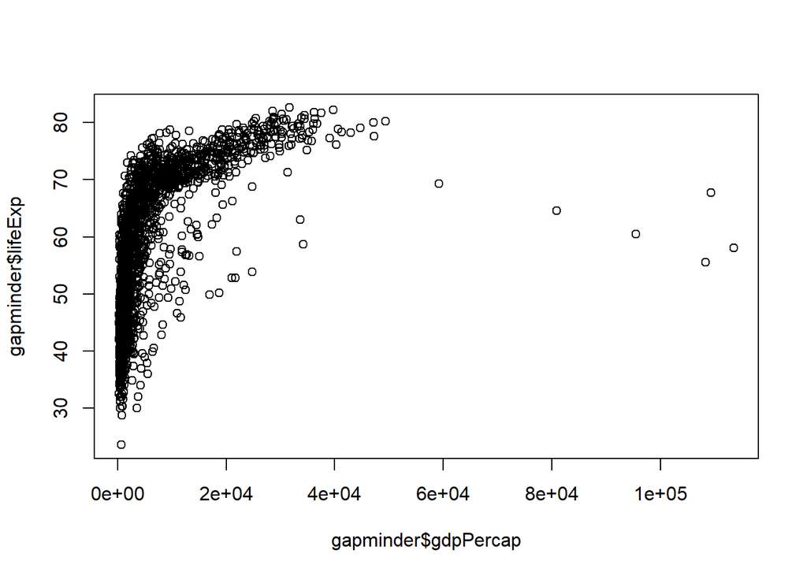

```r
plot(gapminder$gdpPercap, gapminder$lifeExp)
```

2. Add colors by factors with argument `col` (color by continent)

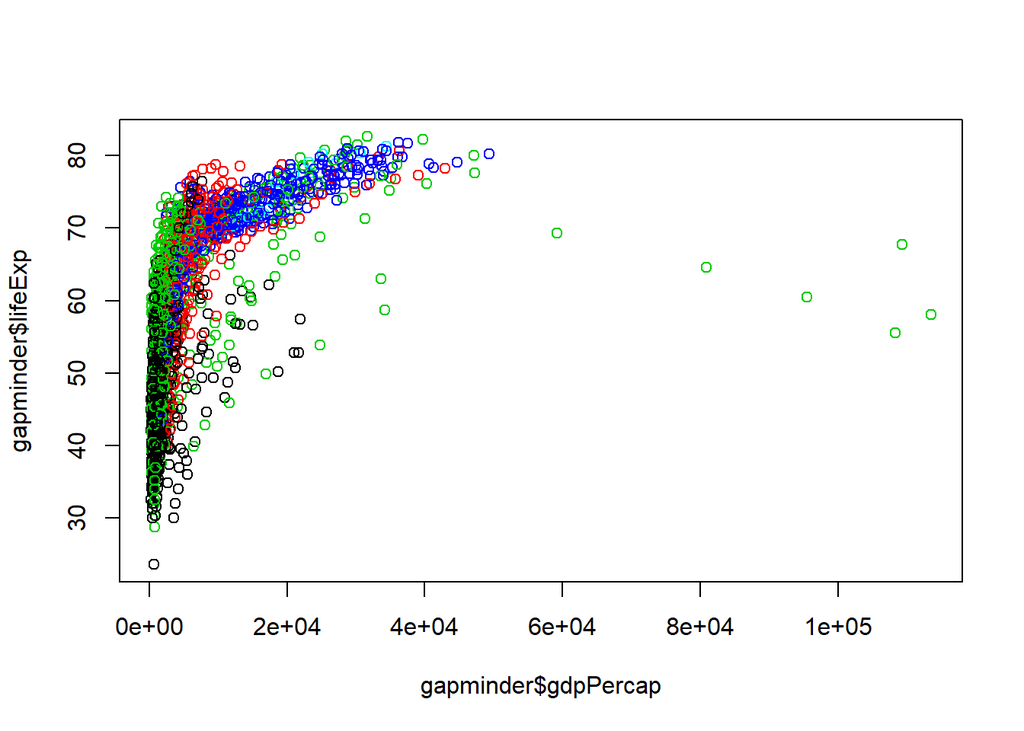

```r
gapminder <- read.table("gapminder.tsv", header = TRUE, sep = "\t")
plot(gapminder$gdpPercap, gapminder$lifeExp, col = gapminder$continent)
```

3. Add titles for the axes with arguments `xlab` and `ylab`, change shape of the symbols with argument `pch` (try different values).

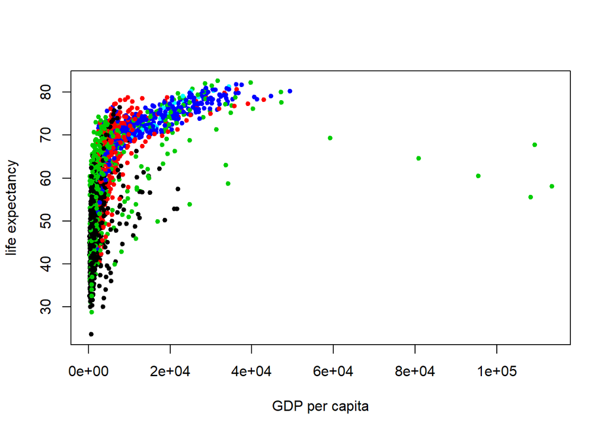

```r
plot(gapminder$gdpPercap, gapminder$lifeExp, col = gapminder$continent, pch = 20, xlab = "GDP per capita", ylab = "life expectancy")
```

4. Add legend with function `legend`.

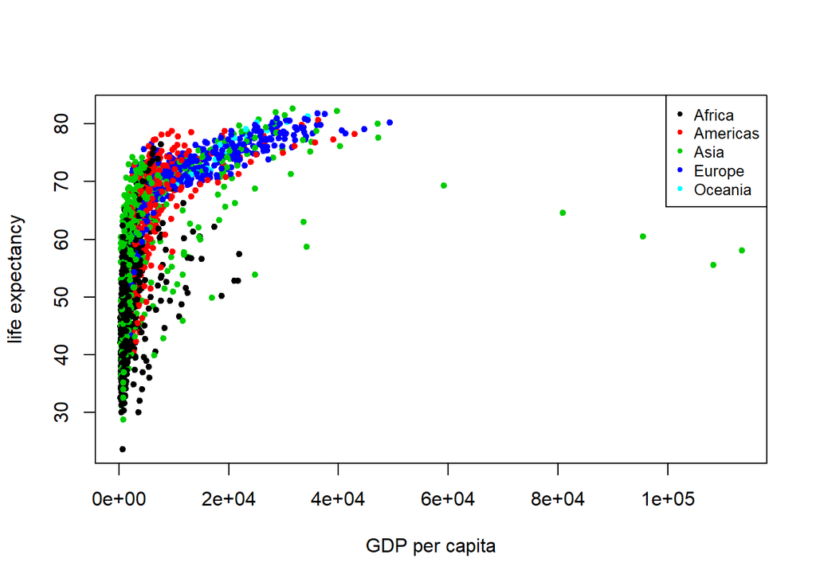

```r
plot(gapminder$gdpPercap, gapminder$lifeExp, col = gapminder$continent, pch = 20, xlab = "GDP per capita", ylab = "life expectancy"); legend('topright', legend = levels(gapminder$continent), col = 1:length(gapminder$continent), cex = 0.8, pch = 20)
```

5. Make histrogram of life expectancy in year 2002 in Afrika and in Europe

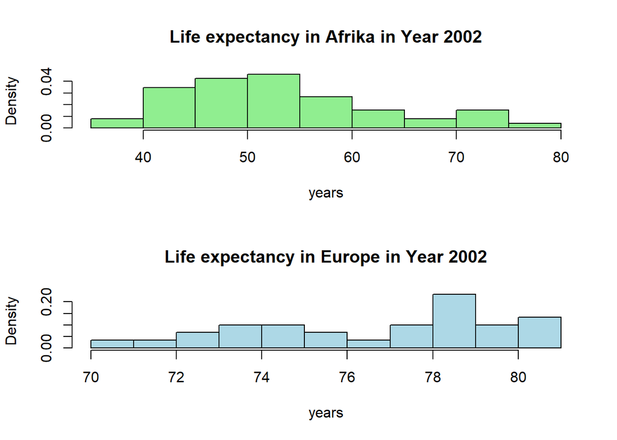

```r
par(mfrow=c(2,1))
hist(gapminder[gapminder$year == 2002 & gapminder$continent == "Africa", ]$lifeExp, freq = F, col = "light green", xlab = "years", main = "Life expectancy in Afrika in Year 2002", breaks = 10, right = F)
hist(gapminder[gapminder$year == 2002 & gapminder$continent == "Europe", ]$lifeExp, freq = F, col = "light blue", xlab = "years", main = "Life expectancy in Europe in Year 2002", breaks = 10, right = F)
```

END of Day 1/2 of Introduction to R and RStudio, Programming in R